# Digital Capacities Index - Quantitative Findings

Liam Magee<sup>1</sup>, Delphine Bellarose<sup>1</sup>, Anjali Sharma<sup>1</sup>, Louise Crabtree<sup>1</sup>, Philippa Collin<sup>1</sup>, Justine Humphry<sup>1</sup>, Paul James<sup>1</sup>, Emma Kearney<sup>1</sup>, Tanya Notley<sup>1</sup>, Amanda Third<sup>1</sup>, Samantha Yorke<sup>2</sup> 1. Western Sydney University 2. Google Australia

4 April 2016

## Digital Capacities Index - Quantitative Findings

The *Digital Capacities Index* is a pilot survey instrument developed by researchers at Western Sydney University and Google Australia. The survey was administered by [Pure Profile](https://www.pureprofile.com/us/) in Febuary 2016.

### Introduction

We included a total of 158 items measuring (a) frequency of various online behaviour, (b) levels of agreement with statements about digital capacities, (c) perceived importance of online activities and (d) ease of use of digital technologies.

We further distinguished questions into the following key thematic areas, or what we have termed, following James (2014), ‘critical issues’. These issues are:

- **Competencies** (42 indicators).
- **Interests** (44 indicators).
- **Resilience** (24 indicators).
- **Social Connectedness** (48 indicators).

These four issues were distilled from a list of nine issues that also included *Engagement*, *Inclusion*, *Policy Environment*, *Infrastructure* and *Consequences*.

Against these four issues, we selected items and scales from existing sources in the literature where possible. In particular we drew from ‘Kids Online’ (Livingstone et al. 2010), Helsper’s (2012) ‘Corresponding fields model’, a study by Humphry (2014) of mobile use among homeless populations, and indicators compiled by the [Young and Well CRC](http://www.youngandwellcrc.org.au/). Other indicators were developed by the *Digital Capacities Index* team.

A large number of candidate scales were distilled down to the current list after two day-long workshops, and testing of the survey.

### Demographics

The survey included a total of 2,157 participants. We requested the survey provider provide a panel in terms of age groups, gender and geographic regions. As the panel provider recruited participants online, our pilot sample is expected to be skewed towards Australian citizens and families with comparatively high digital capacities. This caveat is signficant to the interpretation of our results below.

#### Age

Participant ages ranged from 12 to 91, with a median value of 42.

*Figure 1* provides more detailed age demographics:

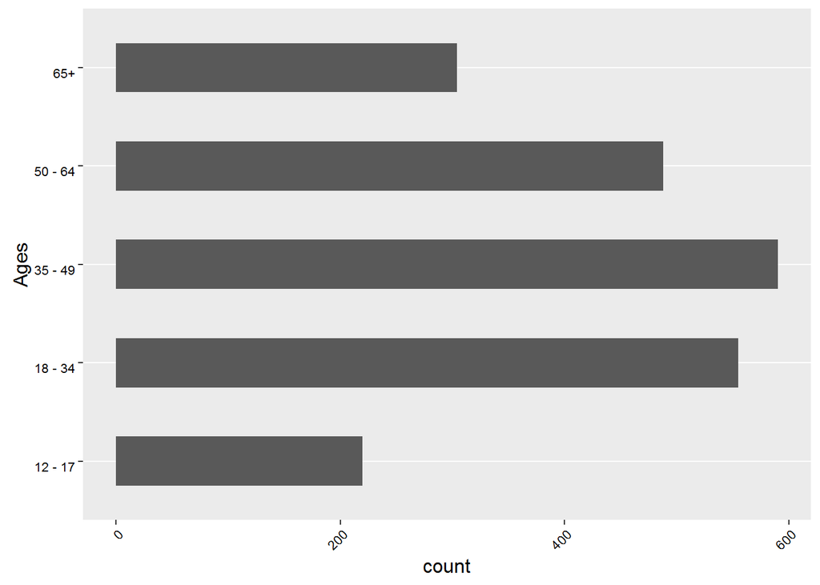

**Figure 1: Age Frequency**

#### Gender

Participant gender is roughly evenly distributed. The survey included 1,105 (51%) women; 1,048 (49%) men; and 4 (0.19%) identifying as ‘Other’.

Gender demographics are distributed, as show in Figure 2:

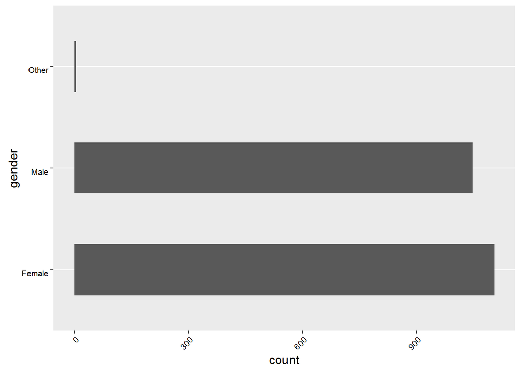

**Figure 2: Gender Frequency**

#### Combined Age and Gender

Combined age and gender demographics are distributed as per *Figure 3:

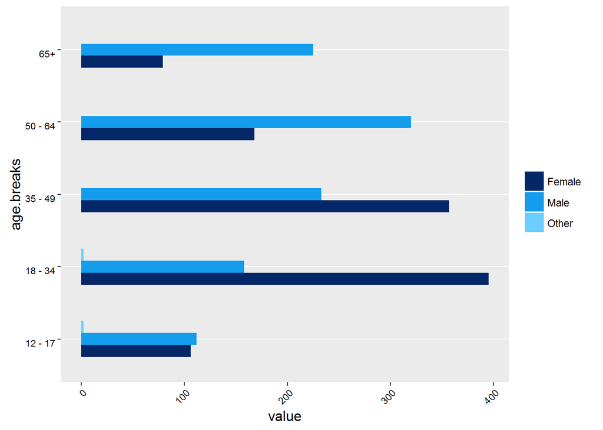

**Figure 3: Age & Gender Frequency**

These figures approximate to Australia’s adult age distribution, as reported by the ABS in 2014 in **Figure 4** below, though with a considerably higher skew towards younger women and older men.

[figure not shown]

**Figure 4: Australia’s Age & Gender Frequency (ABS 2014)**

#### State and Location

Survey distribution by state broadly follows Australia’s demographic distribution.

The split of participants between urban and regional/rural is as follows:

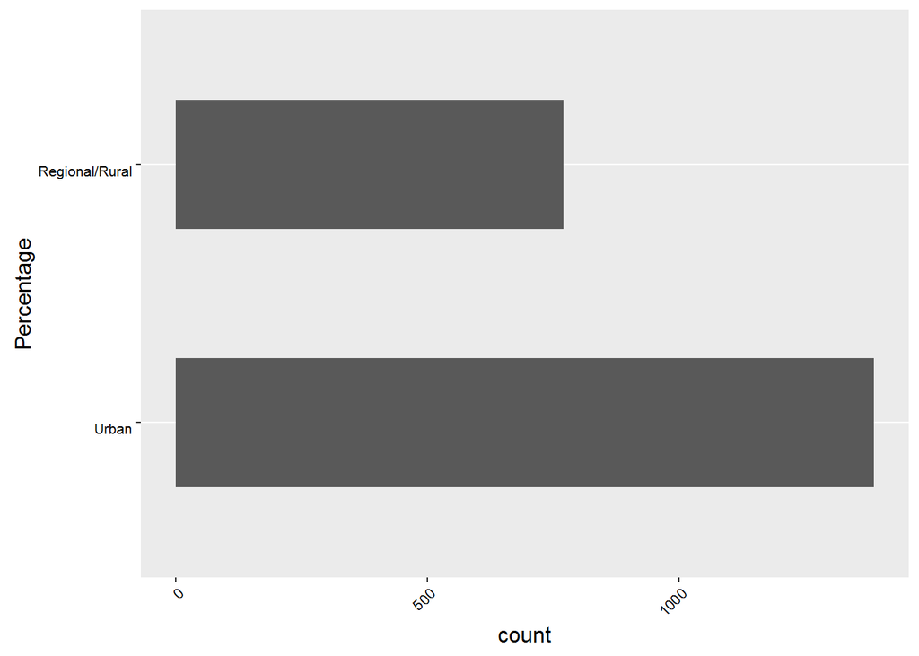

The percentage of reported urban residents here is 64.3 - considerably less than [World Bank figures of 89%](http://data.worldbank.org/indicator/SP.URB.TOTL.IN.ZS).

## Results by Critical Issue - Aggregated

### Competencies

Our survey asked participants to respond to two questions about competencies:

- Frequency of online activity
- Perceived ease of conducting online activity

#### General Results

##### Frequency of online activity

*Frequency of online activity* measures frequency of 15 different activities, ranging from highly common activities such as sending email through to less common activities (in 2016), such as writing blogs.

The graph below shows the relative frequencies of each activity. Using the Internet generally (for work, study, and for personal use), sending email and social networking are the most common activities. Streaming music, playing games with others, sharing media and writing blogs or diaries are comparatively uncommon activities.

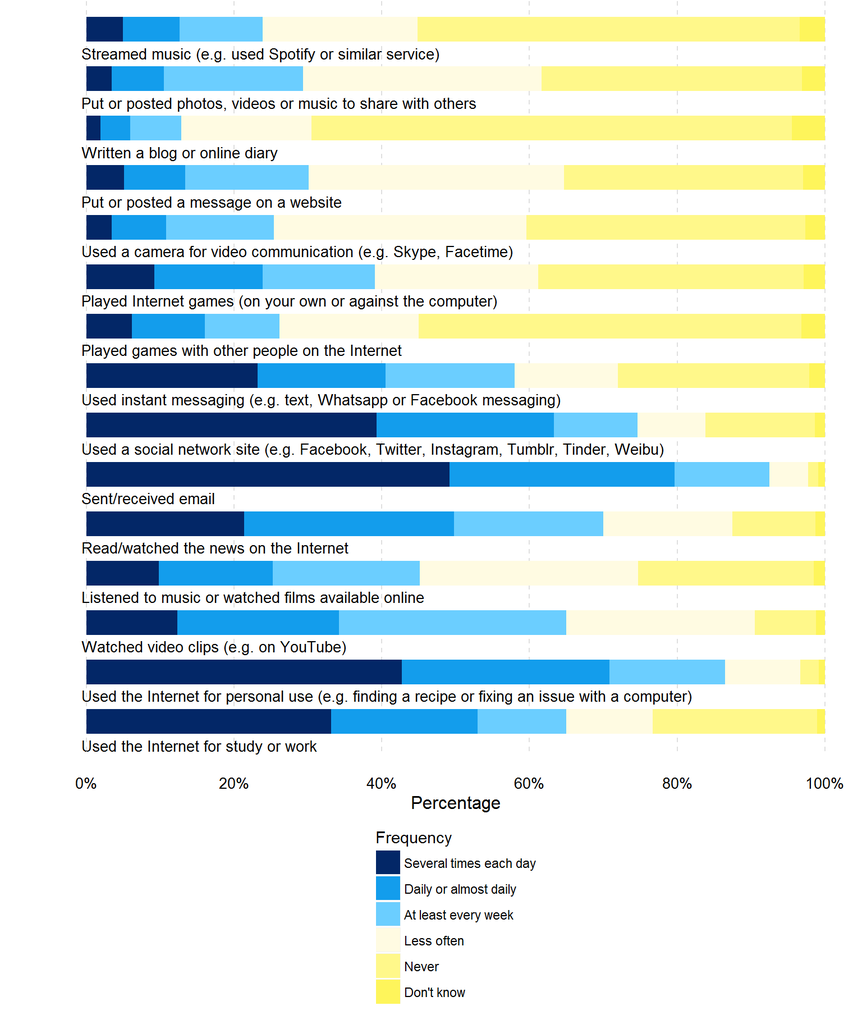

##### Perceived ease of conducting online activity

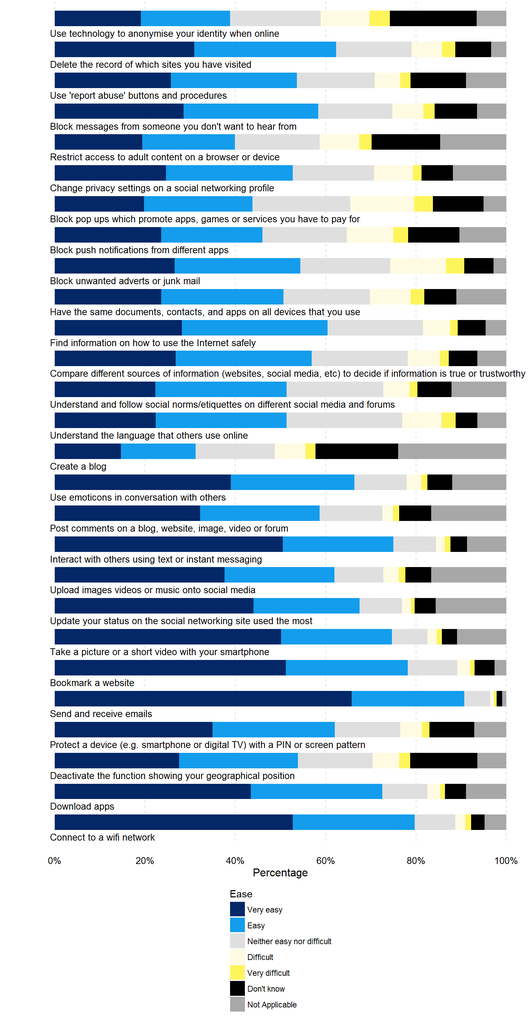

#### Results by Age

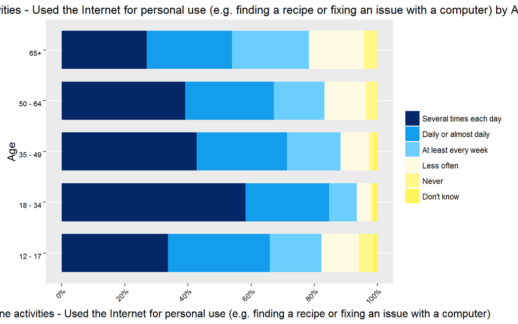

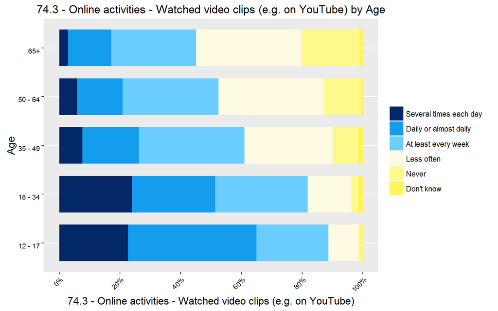

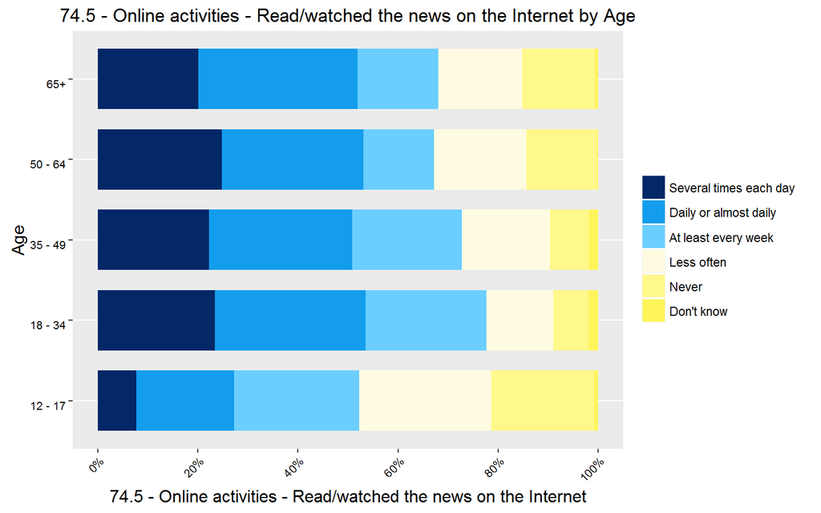

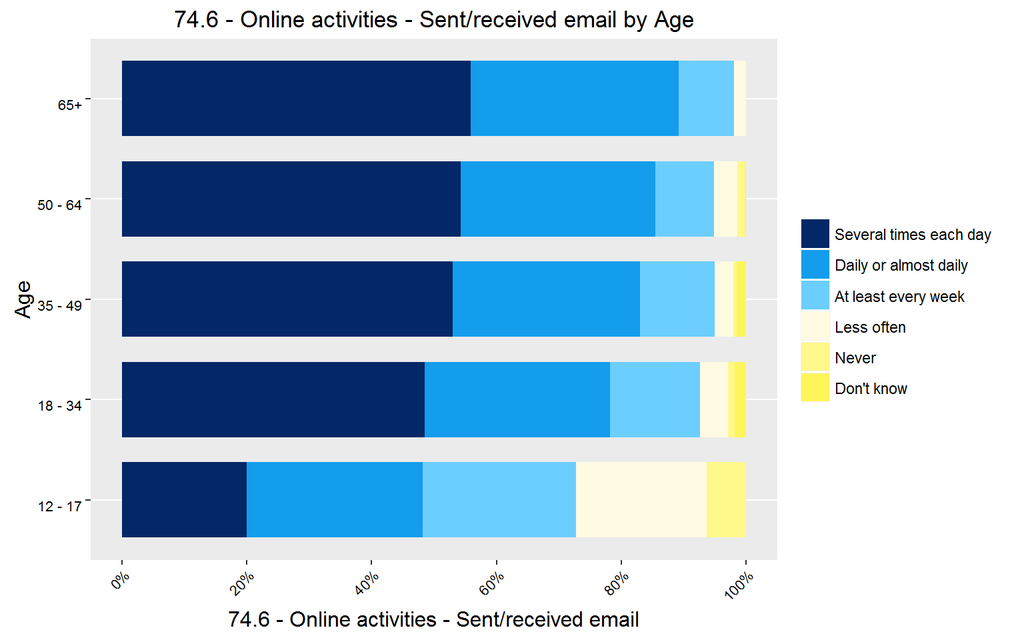

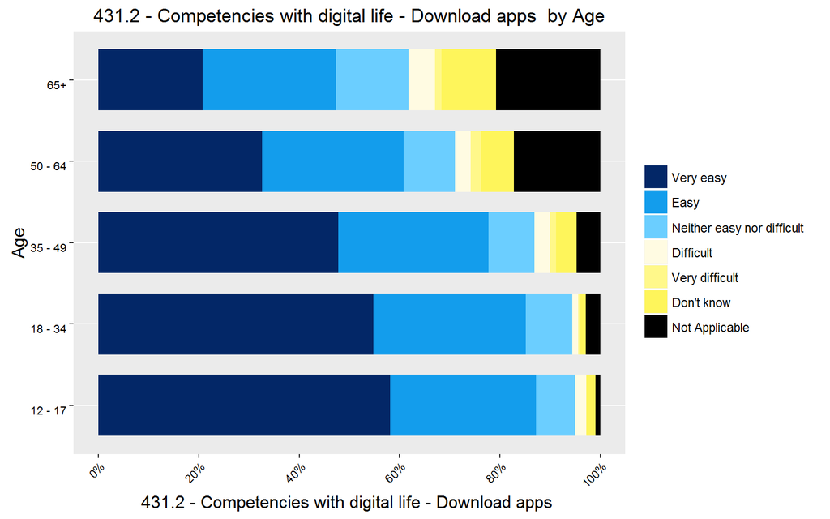

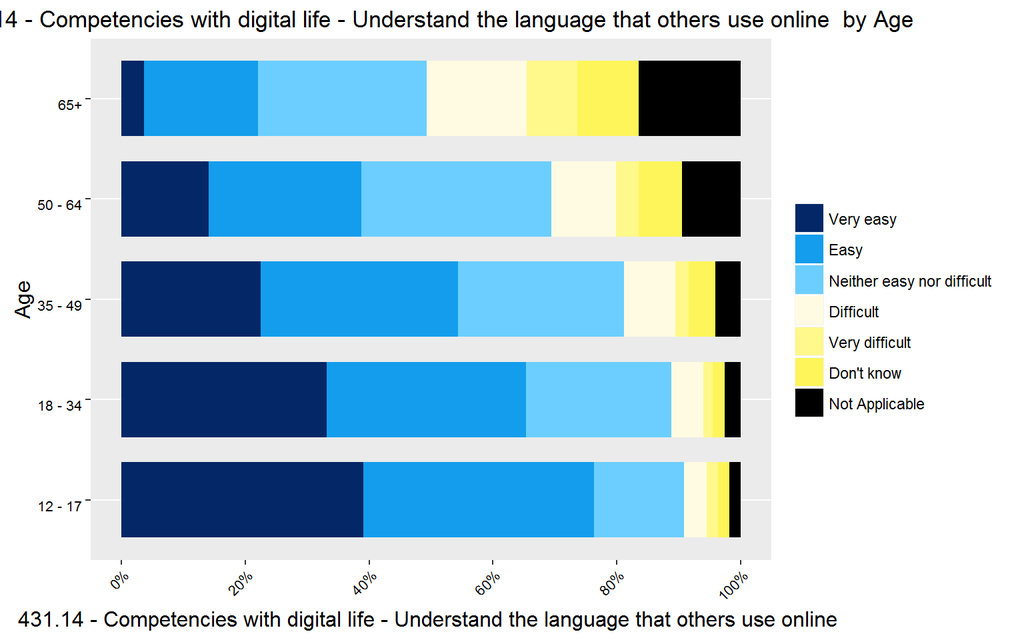

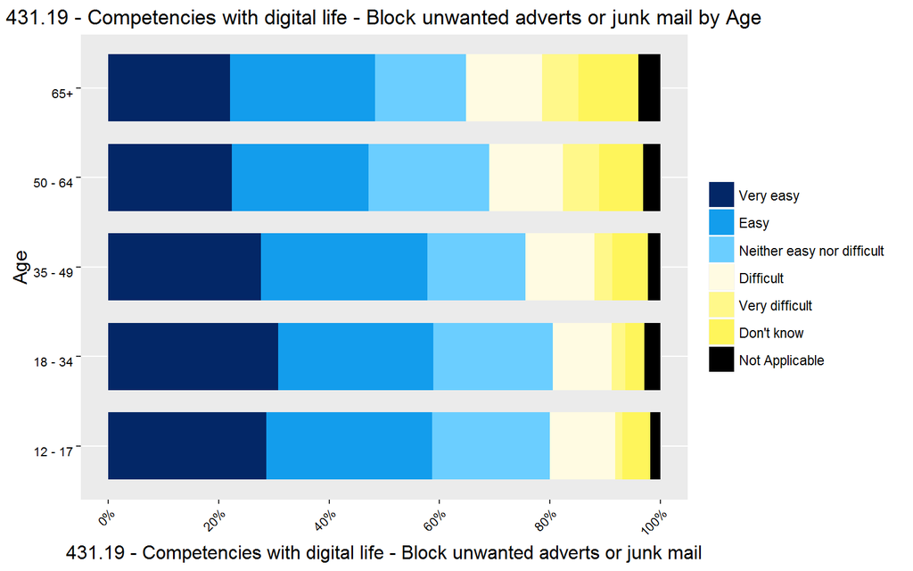

### Interests

#### General Results

##### General Interests

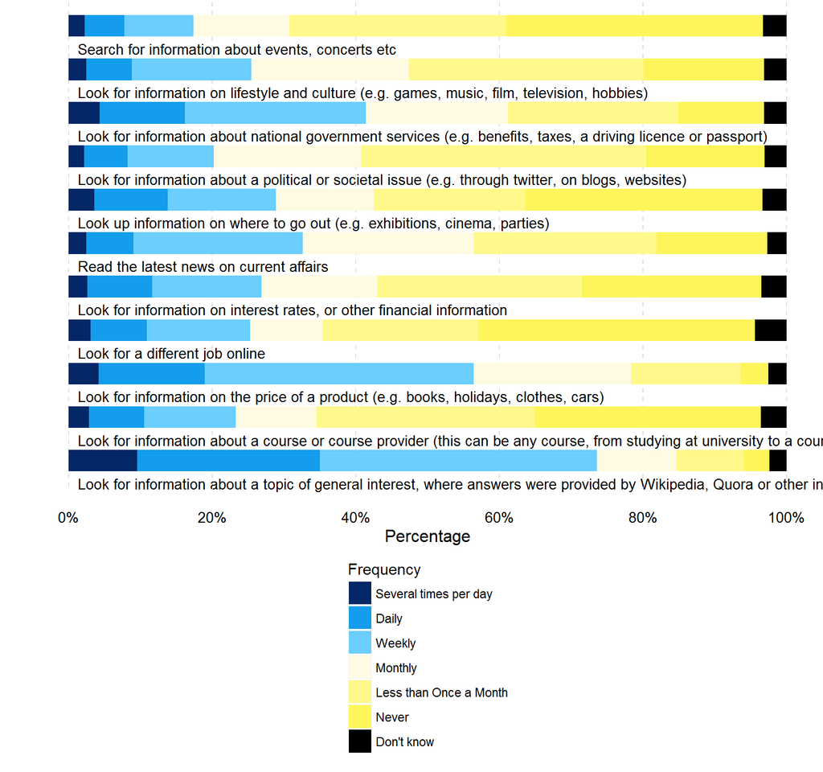

##### Interest in seeking difference

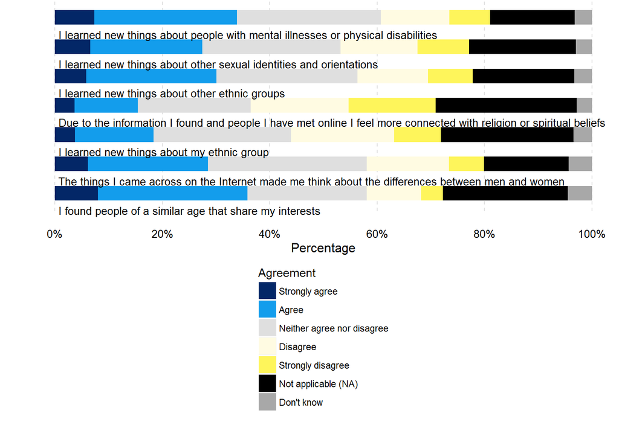

##### Interest in fitness and health improvement

[figure not shown]

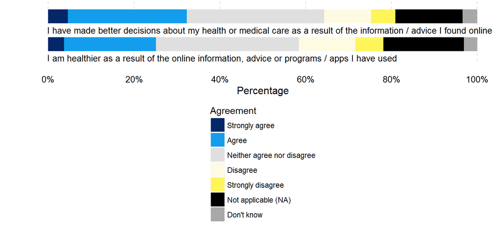

##### Interest in keeping in touch

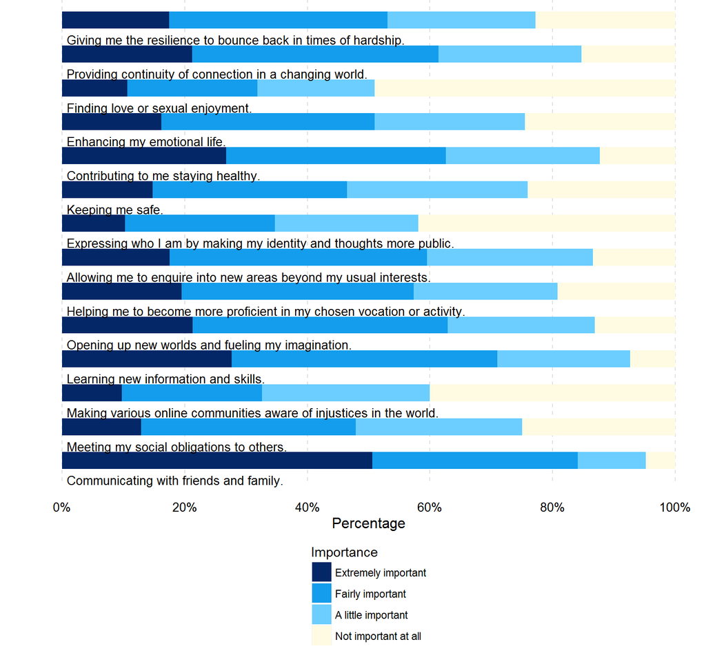

#### Results by Age

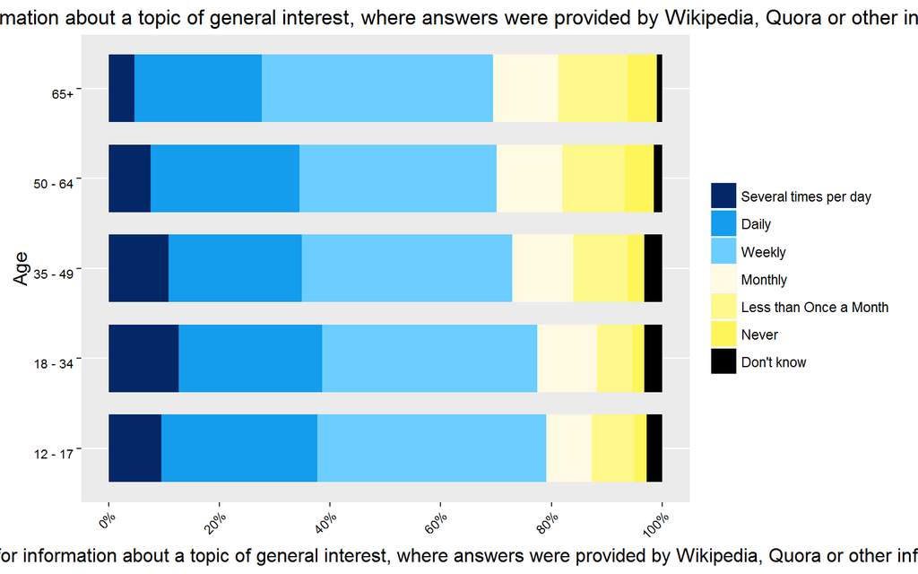

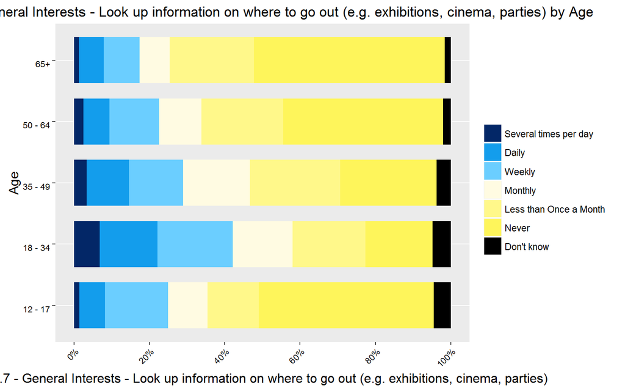

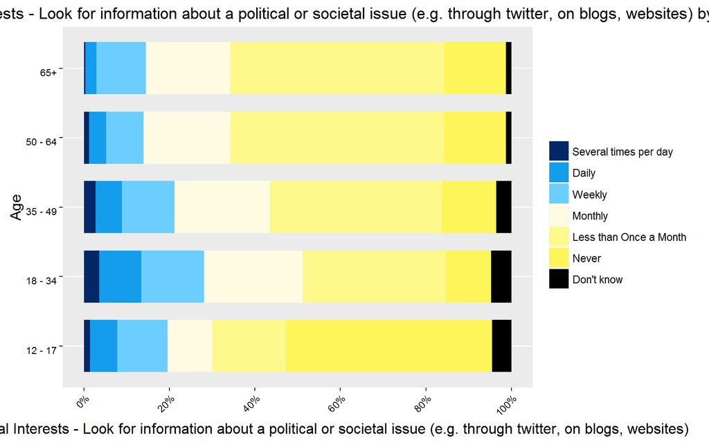

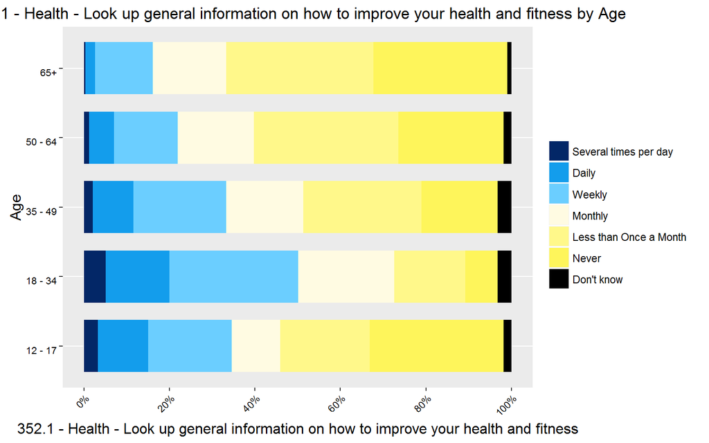

### Resilience

Our survey asked participants to respond to three questions about potential risks and harms of online activity, and how they prepare themselves for dealing with them.

- Experience of potential risks and harms of online activity in the last 12 months
- Level of agreement with statements about potential risks and harms
- Level of agreement with statements about engaging with others online

#### General Results

##### Frequency of harmful events

*Frequency of harmful events* measures frequency of 11 risks of online activity. These include getting a virus on one’s device or seeing upsetting content online, or actions taken as a protection measure against those risks, such as reporting an issue online, deleting data or blocking further contacts from an individual.

**The graph below shows the relative frequencies of experiencing a risk, or taking a specific action in response to a risk, in the last 12 months.**

Half of respondents reported taking protective measures, such as blocking further contacts from an individual or deleting data in response to security and privacy concerns, at least once in the last 12 months.

Although respondents reported experiencing potentially harmful events online, the frequency of such events remains generally low. The most frequently reported action in response to online risks is to use extra security measures to protect privacy.

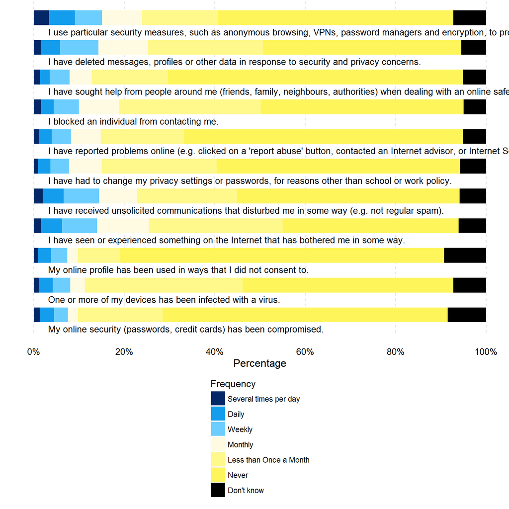

##### Responses to statements about online harms

The graph below shows the level of agreement with a number of statements relating to online harms.

Despite reporting having experienced some potentially harmful events in the last 12 months, the level of agreement with statements about online harms of a more general nature show an overall positive attitude towards those risks. The majority of respondents agree or strongly agree that the opportunities of online activities outweigh its risks and that some level of online risk is inevitable but also provides an important learning opportunity.

Online security and safety remains a pressing concern for just over a third of respondents but there appears to be both an increased level of acceptance and the development of coping mechanisms to better manage the risks.

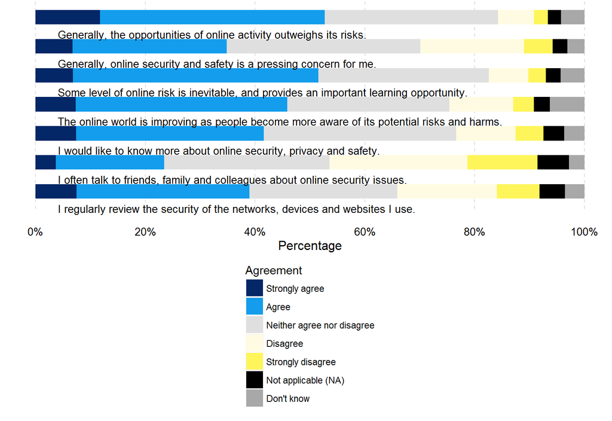

##### Willingness to engage with others

Thinking about how they feel when they engage with others online, respondents were asked to what extent they agree with several statements relating to their willingness to engage with others.

For each statements, a large proportion of respondents neither agree nor disagree. People tend to disagree that it is easier to be oneself online than face to face or that they talk about private things online that they do not share face to face. Similar proportions agree or disagree that going online make them feel better when they are going through a difficult time.

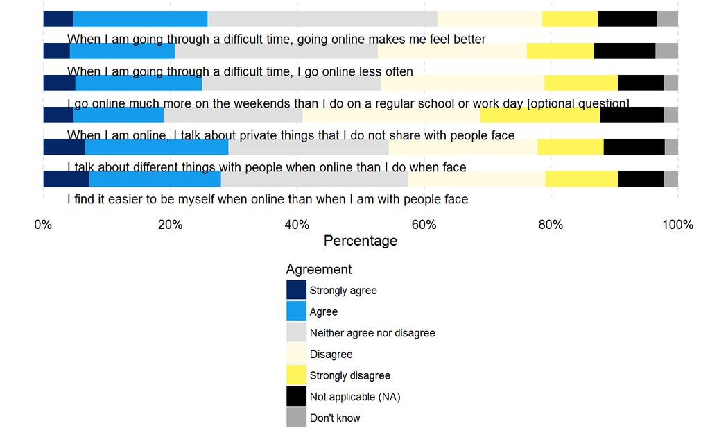

#### Results by Age

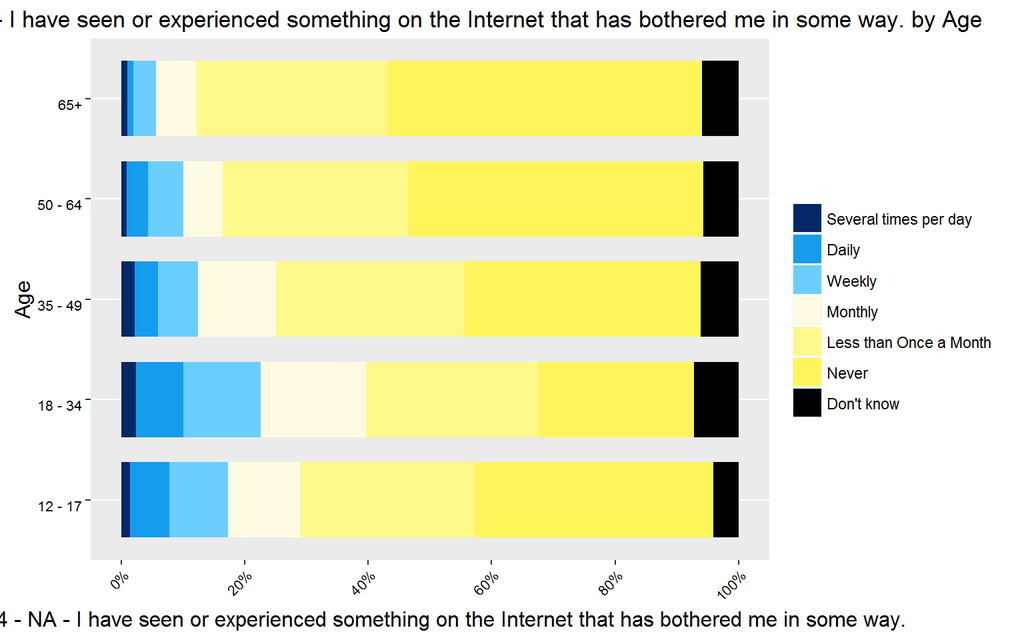

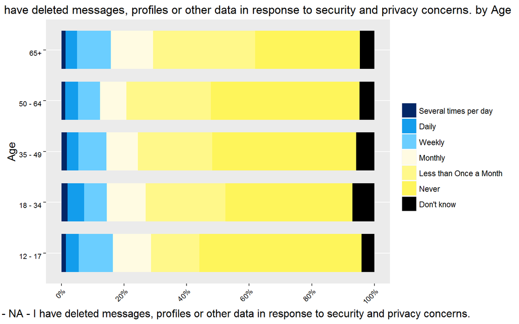

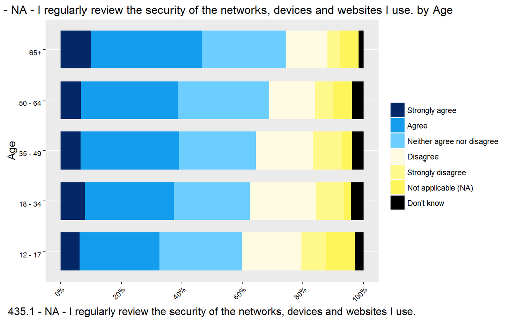

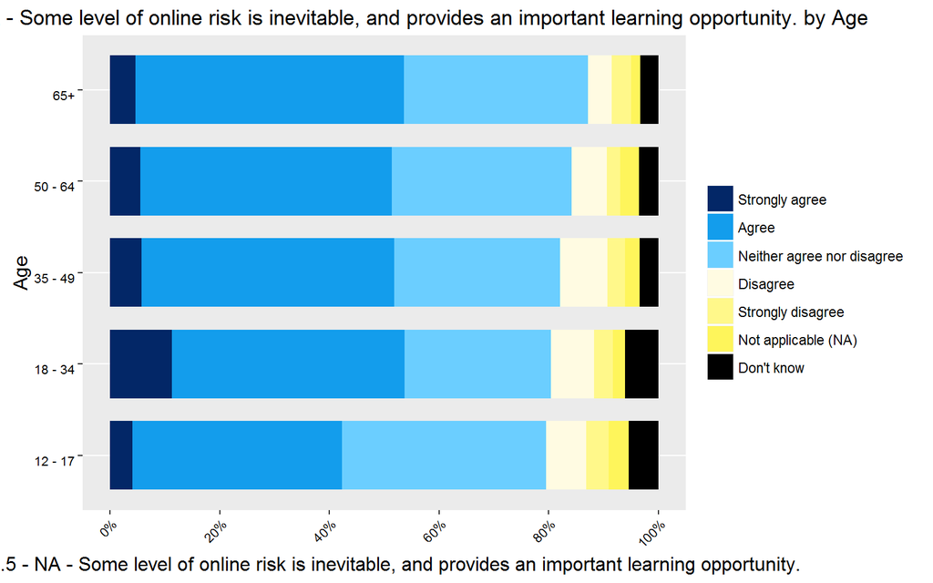

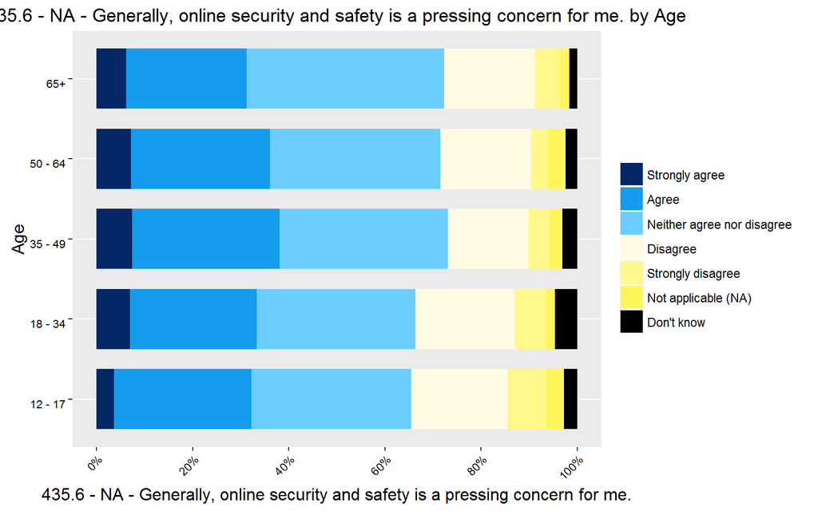

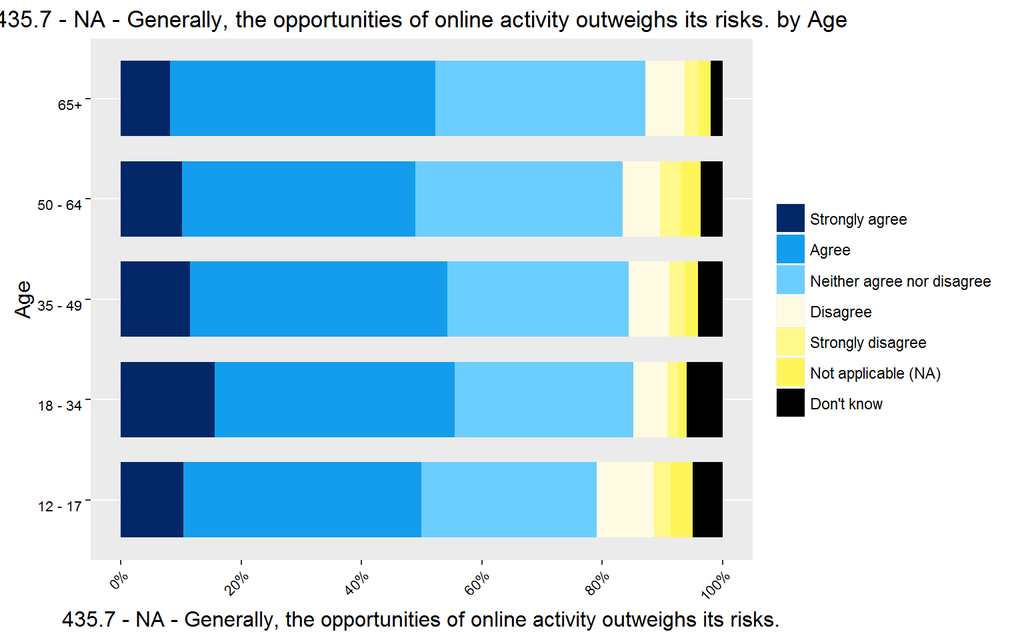

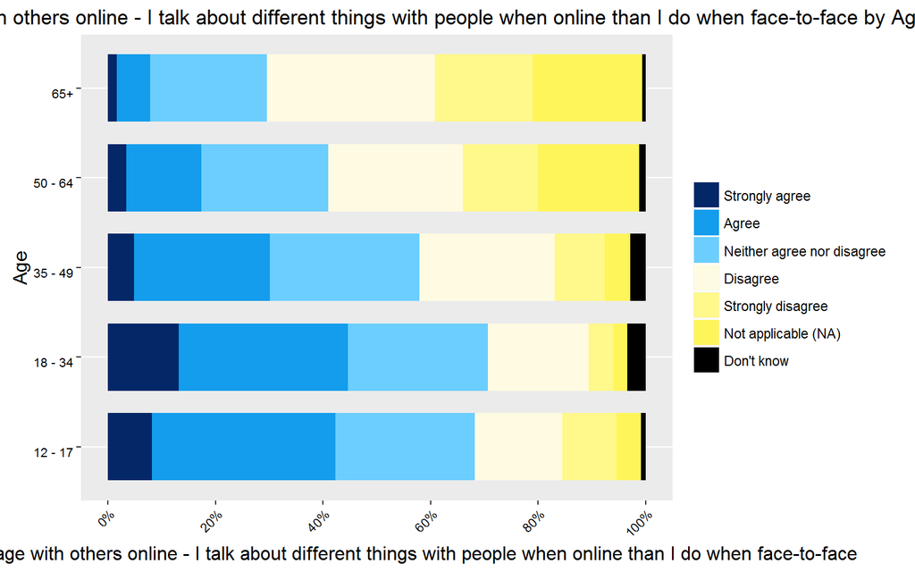